# Module C — Probabilistic Outcome Forecasting

Bayesian Hierarchical Tracking · Calibration Series A · Synthetic Reconstruction

## Context

This report presents the output of the **Module C probabilistic forecasting pipeline** — a Bayesian hierarchical model that aggregates noisy, structurally biased survey measurement signals into a calibrated daily preference-proxy track with full posterior uncertainty.

**Calibration series:** A (valid-preference-proxy share convention; verified anchor margin +3.70 pp). **Reconstruction note:** All inputs are synthetic. Survey measurement records are reconstructed from published ficha técnica summaries. The model is specified to mirror the inferential challenge of the original program.

**Model stack:**

- Latent daily preference-proxy margin follows a non-centered Gaussian random walk

- Survey-measurement firm-level house effects modeled as a non-centered hierarchical normal

- NUTS sampler (PyMC): 4 chains × 1,000 draws (tune 1,000), `target_accept = 0.99`, `max_treedepth = 15`, seed 42

- Monte Carlo scenario engine: 10 000 draws × 3 scenario buckets

## Daily Posterior Forecast Track

(a) Daily posterior preference-proxy margin (pp) with its highest-density-interval band (probability mass in the legend, from config). Survey measurement waves shown as diamonds.

[interactive chart not shown]

Figure 1

**Interpretation:** The posterior mean tracks the direction of the verified outcome. The HDI band is widest on the poll-free mid-program stretches — where the Gaussian random walk prior dominates and the band opens to tens of percentage points — then tightens sharply toward the outcome-anchored terminal date. Expanding the fixture from 4 to 8 survey measurement waves over 142 days pins the track down at more points, but the wide mid-program bands persist: they are a structural consequence of sparse, irregularly-spaced measurements, not a model deficiency. Production use would require a denser measurement cadence; the non-centered reparameterization (model v0.4) already removed the sampler pathology, so the width reflects the data, not the geometry.

## Survey Measurement Firm House Effects

House effects quantify systematic measurement bias per survey firm — the tendency of a firm to systematically over- or under-report the preference proxy for one side relative to the true underlying value.

Table 1: Posterior house effects by survey measurement firm (pp). Wide credible intervals reflect sparse, irregularly spaced survey waves.

[interactive chart not shown]

Figure 2: House effect posterior means with HDI intervals (probability mass from config) — firm-level measurement bias.

## Monte Carlo Scenario Engine

The scenario engine draws 10 000 paths from the posterior and applies engagement-shock multipliers to generate a distribution over possible outcomes. The figure below plots **effective** persuasion contacts per draw (`scenario_adjusted_persuasion_contacts` = baseline handshake mean × per-draw engagement shock). The raw `alloc_mean_persuasion_contacts` scalar is scenario-invariant and is intentionally excluded — plotting it produces a flat line.

[interactive chart not shown]

Figure 3: Monte Carlo draw distribution: effective persuasion contacts (baseline mean × engagement shock) per scenario bucket.

Pooled Monte Carlo shock-scale summary. Equal-thirds stratification across

scenario buckets is a variance-reduction DESIGN, not a claim the three

buckets are equally likely (IMP-C08 / audit C14) — the weighted row below

corrects the pool back to the buckets' empirical prevalence among observed

tracking polls via draw_weight = prevalence(bucket) / design_share(bucket).

| Metric | Value |
| --- | --- |
| Total draws | 10,000 |
| Scenario buckets | 3 |
| Shock scale mean (unweighted — equal-thirds pool, NOT the headline stat) | 1.515 |
| Shock scale std (unweighted) | 0.859 |
| **Shock scale mean (prevalence-weighted — headline)** | **1.387** |
| Effective sample size under weighting (Kish n_eff) | 6274.4 |

## Department-Level Win Probability

Poll-implied win probability per geographic unit (model `c_battleground_v0.5`): each department’s margin tracks the **unanchored** national posterior linearly via its TSJE-derived swing factor; department dispersion uses per-dept σ_idio estimated from reference poll residuals (2013 GRAU/2018 ATI) and a 2013↔︎2018 election cross-section floor (`data/reference/battleground/`). National uncertainty enters without swing scaling (v0.5 decoupled mapping). HDI whiskers propagate national margin uncertainty through percentile sampling on win probability. **Estimand disclosure:** swing factors are derived from the realized 2018 TSJE department results — this is not an out-of-sample forecast. The retrodiction companion table below uses an outcome-anchored national posterior (outcome data enters twice).

[interactive chart not shown]

Figure 4: Poll-implied department win probability with HDI interval — Series A. Unanchored national posterior × outcome-derived swing factors; c_battleground_v0.5 decoupled σ with reference-estimated per-dept σ_idio (see manifest). Diamonds mark TSJE 2018 actual winner.

Battleground poll-implied vs retrodiction companion

The **poll-implied** column is the primary published view (unanchored national posterior × TSJE-derived swing factors). The **retrodiction** column is a calibration diagnostic (outcome-anchored national posterior × the same swing factors). Swing factors remain outcome-derived in both; neither column is an out-of-sample forecast.

Departments whose >0.5 classification flips: none

| Department | poll-implied P(A) | retrodiction P(A) | flip |
| --- | --- | --- | --- |
| Alto Paraguay | 1.000 | 1.000 |  |
| Alto Parana | 0.191 | 0.397 |  |
| Amambay | 0.976 | 0.722 |  |
| Asuncion | 1.000 | 1.000 |  |
| Boqueron | 1.000 | 1.000 |  |
| Caaguazu | 0.537 | 0.515 |  |
| Caazapa | 1.000 | 0.964 |  |
| Canindeyu | 0.987 | 0.748 |  |
| Central | 0.171 | 0.389 |  |
| Concepcion | 0.067 | 0.328 |  |
| Cordillera | 0.388 | 0.469 |  |
| Guaira | 0.998 | 0.850 |  |
| Itapua | 0.734 | 0.574 |  |
| Misiones | 0.999 | 0.831 |  |
| Neembucu | 1.000 | 0.965 |  |
| Paraguari | 1.000 | 0.897 |  |
| Presidente Hayes | 1.000 | 0.939 |  |
| San Pedro | 0.604 | 0.531 |  |

Poll-implied vs retrodiction companion — departments whose classification flips.

[interactive chart not shown]

Figure 5: Poll-implied win probability choropleth — geoBoundaries PRY ADM1 simplified boundaries (Series A). Ochre = low P(Abdo); ultramarine = high; the scale is anchored at the 50% tie. Exterior omitted (no ADM1 polygon). Bar chart above for exact values.

## Sampling Diagnostics

| Diagnostic | Value | Pass criterion | Status |
| --- | --- | --- | --- |
| Chains | 4 | ≥ 4 | ✅ |
| NUTS divergences | 0 | 0 | ✅ |
| Max tree depth hits | 0 | 0 | ✅ |
| Max R̂ (all params) | 1.0077 | ≤ 1.01 | ✅ |
| Min bulk ESS | 1185 | ≥ 400 | ✅ |
| Min tail ESS | 689 | ≥ 400 | ✅ |

Computed from `mcmc_diagnostics_summary.json` (model `c_tracking_hierarchical_v0.4`, 4 chains × 1000 draws, created 2026-10-27T00:09:35.872299+00:00). All convergence gates pass on this run.

## Posterior Predictive Check

Posterior predictive checks (PPC) compare re-simulated data from the fitted model against the actual poll observations. If the model is well-calibrated, observed values should fall within the PPC credible intervals at their nominal rates.

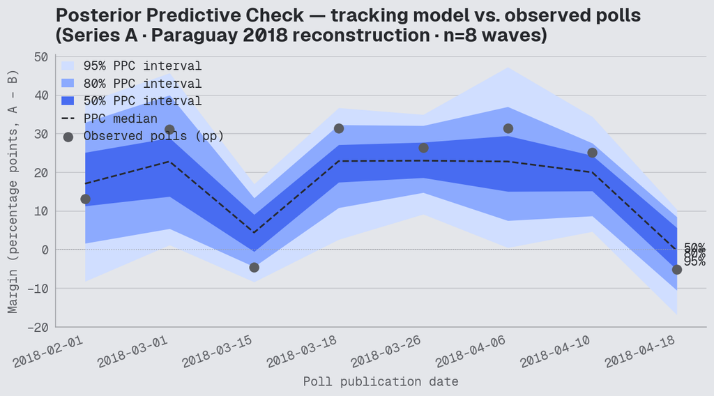

Figure 6: Posterior predictive check: observed polls (grey dots) vs. posterior predictive distribution (ultramarine bands). 50%/80%/95% PPC intervals shown.

| Metric | Value |
| --- | --- |
| Tracking polls (n) | 8 |
| 80% PPC interval coverage | 7/8 = 88% |
| 95% PPC interval coverage | 8/8 = 100% |
| Calibration verdict | **calibrated** |

## Methodology Summary

| Component | Specification | Status |
| --- | --- | --- |
| Prior: daily margin | Non-centered random walk: `mu_margin_init ~ Normal(0, 10)`, innovations `Normal(0, 1)` scaled by `sigma_rw ~ HalfNormal(1.5)` | Implemented |
| Prior: house effects | Non-centered: `house_offset = sigma_house · z`, `z ~ Normal(0, 1)` per survey measurement firm, `sigma_house ~ HalfNormal(2.5)` | Implemented |
| Likelihood: survey measurements | `Normal(mu_t + h_f, sigma_obs)` | Implemented |
| Sampler | NUTS, 4 chains × 1,000 draws, `target_accept=0.99`, 94% HDI intervals | Configured |
| Exit measurement bias | Bayesian regression: intercept + OEA timing + release window flags | Implemented |
| Monte Carlo engine | 10 000 draws × shock scale × scenario bucket | Implemented |
| Battleground mapping | TSJE 2018 swing factors × unanchored national posterior (`c_battleground_v0.5`, poll-implied; σ_idio from reference polls) | Implemented |

**Reproducibility:** `make module-c-all` with `MC_FAST` **unset** re-runs the full-NUTS pipeline (any non-empty `MC_FAST`, including `0`, selects the 50-draw fast path). Sampling is seeded (`random_seed` in `config/pymc_sampler.yaml`); `test_posterior_stability_across_independent_fits` asserts two independent fits agree within 0.05 pp per day.

*Generated from `module_c_forecasting_scenarios/portfolio/quarto/post_mortem.qmd` · Calibration series A only · No real entities represented.*